# Cross-border regimes by scenario, regional setup and external closure

Applying the submitted-label rule to all 96 completed revised observations

Author

LEEDS_MODEL — Oriol Vallès Codina

Published

October 2, 2026

**Written:** 2 October 2026. **Evidence:** `R/scenarios/transmission_regimes.R`, the accepted-grid input/response CSVs, the scenario registry, and remeasured submitted reference caches. **Computation:** `R/scenarios/classify_transmission_grid.R`. Source checkpoint `5f1a172`; original pooled clustering `caa5d01`. Claims marked calculated below come from the new classification files, not from carrying earlier prose forward. The manuscript and scenario definitions are unchanged.

## What was classified

This report applies the same stated rule that reproduces the submitted paper’s twelve manually assigned cross-border regime labels to **all 96 completed revised-grid observations**. Twelve scenarios, numbered 1–4 and 6–13, are crossed with two regional aggregations and four external-account closures. The two aggregations are European Union/rest of world (EU/RoW) and North/South; the closures are fixed-rate gold settlement, fixed-rate fiat reserve adjustment, OPENFIXG government-spending adjustment, and quasi-floating exchange-rate adjustment. Each aggregation × closure combination is an **arm**.

The classification concerns value-added responses at period 90 relative to each arm’s own baseline. It is a sign-and-threshold description of cross-border activity, not an unsupervised clustering result or independent proof of the mechanism named by the label. No construction scenario 5 or 14 enters the analysis. Submitted observations are remeasured only to validate the rule and provide the original label alongside the revised matrix; they are not added to the 96-observation pool.

**Calculated:** six of twelve scenarios retain one label across all eight arms: 3, 6, 7, 8, 11 and 12 are SC throughout. The other six change classification with the regional setup, closure, or both. Gold, fiat and quasi-floating closures have identical labels within each setup at the default threshold, despite differences in response magnitudes. OPENFIXG changes six EU/RoW labels and one North/South label relative to gold.

## The rule and the meaning of its labels

Let $a$ and $b$ be the Z1 and Z2 value-added responses, measured as $100\times(\mathrm{scenario}/\mathrm{baseline}-1)$. Z1 is EU or North; Z2 is RoW or South. Use the submitted-calibrated threshold $\tau=0.003\%$ and apply the following conditions **in this order**:

| Condition | Label | What the response actually says |
| --- | --- | --- |
| $\|b\|<\tau$ | SC | Z2 activity response is below the fitted transmission threshold, regardless of the sign of either region |
| Otherwise $a<0,b>0$ | PL — production leakage | Z1 contracts and Z2 expands |
| Otherwise $a>0,b<0$ | CD — competitive displacement | Z1 expands and Z2 contracts; use FIC for the energy scenarios 2 and 13 |
| Otherwise $a<0,b<0$ | SC — symmetric contraction | Both regions contract |
| Otherwise | UN — outside the original four labels | In the observed default grid, both regions expand |

FIC means **fossil import collapse**, the submitted name applied to scenarios 2 and 13 when they satisfy the expansion/contraction condition. Retaining this name reproduces the classification convention; the label itself does not establish an energy-trade causal mechanism in every recalibrated arm. Likewise PL/CD labels are not independently confirmed by unsupervised response clusters.

The SC abbreviation is inherited but combines two distinct decision branches. A sub-threshold Z2 response can coexist with a positive Z1 response, and even with two expansions. Therefore the matrix preserves the original labels while a second display distinguishes **SCw**, assigned by the weak-Z2 threshold, from **SCc**, assigned because both regions contract after passing the threshold test. These are explanatory branch tags, not replacement regimes. Raw regional signs and both VA responses remain available for every observation.

The implementation is checked against the 96 labels already recorded after pooled clustering. It also remeasures all twelve submitted references at period 90 and reproduces **12 of 12 original labels** at the default threshold. The threshold is inherited rather than fitted again to revised observations.

## Every scenario under every arm

EU/RoW classification. Each revised cell is one accepted observation at period 90; the submitted column is the original reference label.

| Scenario | Submitted | Gold | Fiat | OPENFIXG | Quasi-float |
| --- | --- | --- | --- | --- | --- |
| 1 HH food | PL | PL | PL | SC | PL |
| 2 HH energy | FIC | FIC | FIC | SC | FIC |
| 3 HH wood | SC | SC | SC | SC | SC |
| 4 Gov plastics | PL | PL | PL | SC | PL |
| 6 Firm investment metals | SC | SC | SC | SC | SC |
| 7 Production wood | SC | SC | SC | SC | SC |
| 8 Production pulp | SC | SC | SC | SC | SC |
| 9 Production plastics | PL | PL | PL | SC | PL |
| 10 Production metals | CD | CD | CD | SC | CD |
| 11 Production glass | SC | SC | SC | SC | SC |
| 12 Production cement | SC | SC | SC | SC | SC |
| 13 Production energy | FIC | FIC | FIC | SC | FIC |

North/South classification. Each revised cell is one accepted observation at period 90; the submitted column is the original reference label.

| Scenario | Submitted | Gold | Fiat | OPENFIXG | Quasi-float |
| --- | --- | --- | --- | --- | --- |
| 1 HH food | PL | PL | PL | UN | PL |
| 2 HH energy | FIC | FIC | FIC | FIC | FIC |
| 3 HH wood | SC | SC | SC | SC | SC |
| 4 Gov plastics | PL | SC | SC | SC | SC |
| 6 Firm investment metals | SC | SC | SC | SC | SC |
| 7 Production wood | SC | SC | SC | SC | SC |
| 8 Production pulp | SC | SC | SC | SC | SC |
| 9 Production plastics | PL | SC | SC | SC | SC |
| 10 Production metals | CD | SC | SC | SC | SC |
| 11 Production glass | SC | SC | SC | SC | SC |
| 12 Production cement | SC | SC | SC | SC | SC |
| 13 Production energy | FIC | FIC | FIC | FIC | FIC |

The full machine-readable matrix is `matrix.csv`, and `observations.csv` has one row per accepted scenario/arm observation with signed VA responses, the branch used, the threshold margin, baseline and shock paths/hashes, and supporting material, employment, government-spending and external-account responses.

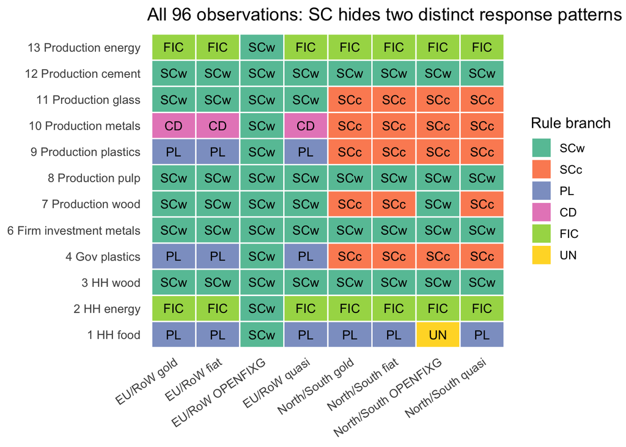

**Calculated:** the 96 default labels comprise **66 SC, 12 PL, 14 FIC, 3 CD and 1 UN**. Of the 66 SC cells, 47 are assigned by the weak-Z2 branch and 19 by the both-contracting branch. Nineteen of the 96 revised cells differ from their scenario’s submitted reference label. These counts summarise a crossed deterministic grid; they are not independent replications of twelve interventions.

## Where the regional and closure interactions appear

**Scenarios 4 and 9, plastics in government consumption and production.** EU/RoW gold, fiat and quasi-float all produce PL: EU contracts while RoW expands. Under North/South those same closures produce contractions in both regions and therefore SCc. EU/RoW OPENFIXG instead suppresses the RoW response below the fitted threshold (SCw). North/South OPENFIXG still produces two contractions (SCc). Thus equal SC labels under OPENFIXG conceal different reasons for classification.

**Scenario 10, production metals.** EU/RoW gold, fiat and quasi-float produce CD, with EU expansion and RoW contraction. All four North/South closures produce contraction in both regions, classified SCc. EU/RoW OPENFIXG has an even larger positive Z1 VA response, but its Z2 contraction is smaller than the fitted threshold, yielding SCw. Moving from CD to SC does not mean the domestic expansion disappears; it means the cross-border magnitude falls below the rule’s cutoff.

**Scenarios 2 and 13, household and production energy.** Both regional setups give FIC under gold, fiat and quasi-float. North/South OPENFIXG retains FIC. EU/RoW OPENFIXG instead gives a small positive Z2 response below the threshold and a positive Z1 response, classified SCw. This differs from a symmetric contraction in both sign and mechanism.

**Scenario 1, household food.** Both setups give PL under gold, fiat and quasi-float. EU/RoW OPENFIXG gives a strong Z1 contraction but a weak Z2 contraction, classified SCw. North/South OPENFIXG expands both regions, giving UN because the original taxonomy has no symmetric-expansion category. Forcing this observation into one of the four submitted labels would discard an observed response pattern.

Worked interaction examples: gold versus OPENFIXG. VA values are percent deviations from each arm’s own baseline, not percentage points of income shares.

| scenario | setup | closure | va_Z1 | va_Z2 | regime | rule_branch |
| --- | --- | --- | --- | --- | --- | --- |
| 1 | EU/RoW | openfix_gold | -0.031831 | 0.014380 | PL | PL: Z1 contracts, Z2 expands |
| 1 | EU/RoW | openfixg | -0.137812 | -0.001186 | SC | SC: weak Z2 response |
| 1 | North/South | openfix_gold | -0.017971 | 0.058696 | PL | PL: Z1 contracts, Z2 expands |
| 1 | North/South | openfixg | 0.009494 | 0.200252 | UN | UN: both regions expand |
| 2 | EU/RoW | openfix_gold | 0.043487 | -0.005279 | FIC | FIC: energy, Z1 expands, Z2 contracts |
| 2 | EU/RoW | openfixg | 0.080894 | 0.000200 | SC | SC: weak Z2 response |
| 2 | North/South | openfix_gold | 0.027245 | -0.014550 | FIC | FIC: energy, Z1 expands, Z2 contracts |
| 2 | North/South | openfixg | 0.020687 | -0.048313 | FIC | FIC: energy, Z1 expands, Z2 contracts |
| 4 | EU/RoW | openfix_gold | -0.007415 | 0.009630 | PL | PL: Z1 contracts, Z2 expands |
| 4 | EU/RoW | openfixg | -0.077619 | -0.000725 | SC | SC: weak Z2 response |
| 4 | North/South | openfix_gold | -0.012678 | -0.004658 | SC | SC: both regions contract |
| 4 | North/South | openfixg | -0.014540 | -0.014294 | SC | SC: both regions contract |
| 9 | EU/RoW | openfix_gold | -0.012803 | 0.009848 | PL | PL: Z1 contracts, Z2 expands |
| 9 | EU/RoW | openfixg | -0.067963 | 0.001887 | SC | SC: weak Z2 response |
| 9 | North/South | openfix_gold | -0.014787 | -0.006923 | SC | SC: both regions contract |
| 9 | North/South | openfixg | -0.014471 | -0.005397 | SC | SC: both regions contract |
| 10 | EU/RoW | openfix_gold | 0.032694 | -0.014378 | CD | CD: Z1 expands, Z2 contracts |
| 10 | EU/RoW | openfixg | 0.115718 | -0.002426 | SC | SC: weak Z2 response |
| 10 | North/South | openfix_gold | -0.007173 | -0.075224 | SC | SC: both regions contract |
| 10 | North/South | openfixg | -0.032226 | -0.205427 | SC | SC: both regions contract |
| 13 | EU/RoW | openfix_gold | 0.093196 | -0.006466 | FIC | FIC: energy, Z1 expands, Z2 contracts |
| 13 | EU/RoW | openfixg | 0.148000 | 0.001395 | SC | SC: weak Z2 response |
| 13 | North/South | openfix_gold | 0.087800 | -0.010672 | FIC | FIC: energy, Z1 expands, Z2 contracts |
| 13 | North/South | openfixg | 0.077688 | -0.062873 | FIC | FIC: energy, Z1 expands, Z2 contracts |

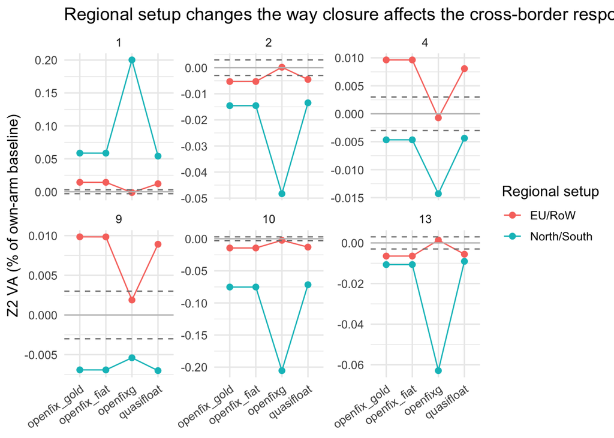

Holding scenario and closure fixed, three of twelve regional comparisons change labels in each closure. But the affected scenarios change: gold/fiat/quasi-float differ between aggregations for **4, 9 and 10**, whereas OPENFIXG differs for **1, 2 and 13**. This is a concrete region × closure × scenario interaction in the classification, not merely a common effect of North/South aggregation on every intervention.

All twelve label changes among the 48 matched regional comparisons.

| scenario | closure | regime_EU_RoW | regime_North_South |
| --- | --- | --- | --- |
| 1 | openfixg | SC | UN |
| 10 | openfix_fiat | CD | SC |
| 10 | openfix_gold | CD | SC |
| 10 | quasifloat | CD | SC |
| 13 | openfixg | SC | FIC |
| 2 | openfixg | SC | FIC |
| 4 | openfix_fiat | PL | SC |
| 4 | openfix_gold | PL | SC |
| 4 | quasifloat | PL | SC |
| 9 | openfix_fiat | PL | SC |
| 9 | openfix_gold | PL | SC |
| 9 | quasifloat | PL | SC |

All seven label changes among the 72 non-gold-versus-gold comparisons, matching setup and scenario.

| scenario | setup | closure | regime_gold | regime |
| --- | --- | --- | --- | --- |
| 1 | EU/RoW | openfixg | PL | SC |
| 1 | North/South | openfixg | PL | UN |
| 10 | EU/RoW | openfixg | CD | SC |
| 13 | EU/RoW | openfixg | FIC | SC |
| 2 | EU/RoW | openfixg | FIC | SC |
| 4 | EU/RoW | openfixg | PL | SC |
| 9 | EU/RoW | openfixg | PL | SC |

## How this relates to the ANOVA result

The companion report `qmd/reports/2026-10-02-transmission-variance-and-cluster-structure.qmd` decomposes the standardised, equally block-weighted full response variation. Across all 96 cells, scenario main differences contribute **53.7%**, scenario × setup **20.3%**, scenario × closure **11.8%**, and the three-way interaction **12.8%**. Other components contribute the remaining approximately 1.4%. Those percentages describe all six outcome blocks and both regions; they are not shares of regime labels or shares of raw VA variance alone.

The classification examples identify where interactions visibly cross a qualitative boundary. ANOVA also detects changes of magnitude within the same label. Gold and fiat can therefore agree on every regime at period 90 while differing in fiscal and financial responses. Conversely a small movement around the fitted threshold can change a regime label without a large change in the full response vector. Neither method validates the other by itself.

The complete 12 × 2 × 4 grid has one deterministic run per cell. Full factorial ANOVA leaves no residual degrees of freedom for a random-error estimate, so its sums-of-squares decomposition is descriptive rather than a conventional F-test. Different regional aggregations and closures also have their own calibrated baselines; the comparisons do not isolate a single structural parameter’s causal effect.

## Threshold sensitivity and limits

The submitted labels admit more than one threshold. We verify that **0.0011%, 0.0030% and 0.0049%** each reproduce all twelve original reference labels, then apply those same choices to the revised grid. Relative to the default, the lower threshold changes **five of 96 labels**, and the upper threshold changes **one**. A zero threshold, which removes the weak-response branch, changes **29 of 96 labels** but does not reproduce the submitted classification. A threshold-free sign classification therefore answers a different question.

Sensitivity relative to τ = 0.003%; all revised observations are retained at every threshold.

| tau_percent | changed_of_96 |
| --- | --- |
| 0.0000 | 29 |
| 0.0011 | 5 |
| 0.0030 | 0 |
| 0.0049 | 1 |

Every change at the two alternative thresholds that still reproduce the submitted labels.

| scenario | arm | tau_percent | regime | sensitivity_regime |
| --- | --- | --- | --- | --- |
| 3 | revised_ns_openfixg | 0.0011 | SC | CD |
| 9 | revised_openfixg | 0.0011 | SC | PL |
| 10 | revised_openfixg | 0.0011 | SC | CD |
| 12 | revised_ns_quasifloat | 0.0011 | SC | UN |
| 13 | revised_openfixg | 0.0011 | SC | UN |
| 2 | revised_quasifloat | 0.0049 | FIC | SC |

The SC label is especially sensitive when OPENFIXG holds the Z2 response close to zero. Mechanistic claims such as production leakage require supporting trade, production-origin and material-flow evidence, not only signs of regional VA. Functional distribution, ecological outcomes and fiscal adjustment are absent from this particular decision rule, although they enter the separate clustering/ANOVA analysis.

These finite-horizon labels do not establish a new stationary fiat or quasi-floating equilibrium. They do not extend to OPENFLEX or omitted construction scenarios. Scenario 6 remains included as simulated; its small response does not settle the intended replacement-capital substitution. The four maintainer decisions remain open. No manuscript label or passage is changed by this report.

## Reproduce and inspect

```bash
Rscript R/scenarios/classify_transmission_grid.R
quarto render qmd/reports/2026-10-02-cross-border-regimes-by-region-and-closure.qmd --to html --output-dir "$PWD/output/html/reports"
```

`output/calibration/transmission_regime_grid_20261002/observations.csv` contains the 96 classified cells and full input provenance; `matrix.csv` provides the scenario × arm table; `scenario_stability.csv` and `counts.csv` summarise labels and branches; `region_comparisons.csv` and `closure_comparisons.csv` preserve matched contrasts; `threshold_sensitivity.csv` preserves all 384 threshold/classification cells; `submitted_rule_validation.csv` records the twelve archived reference calculations and shock hashes; `provenance.json` records code/input/reference hashes and the scope. The original rule is `R/scenarios/transmission_regimes.R`. Accepted simulations were not repeated, and no earlier model cache or clustering output was overwritten.